# Feature_Model Summary

Cherry

11/18/2019

## Chapter 4 - Feature Selection

We created three main types of features. More details are showing as below.

### 4.1 User features

User features are related to the ordering information of each customer. Each row of these features specifies distinct user.

n.o.u(feature1): The number of orders for each user. This feature is acquired by grouping users and by counting the number of orders.

n.p.u(feature2): The number of products for each user. This feature is calculated by grouping users and by counting the total number of products.

avg.pou(feature3): Average number of products per user ordered. This feature is equal to the total amount of products purchased by per user divided by the number of orders per user.

d.m.p(feature4): The day on which each user ordered most frequently. We calculated the number of products per user ordered in each day and selected the day on which per user placed most number of orders as the value of this feature.

t.m.o(feature5): The time of a day on which each user ordered most frequently. We calculated the number of products in each hour per user ordered and selected the hour on which per user placed most orders as the value of this feature.

ror.u(feature6): Reordered ratio per user. Reordered ratio is the number of reordered products divided by the total number of products for each user.

o.f(feature7): Shopping frequency for each user. This variable is derived from dividing the total time interval of orders by the total number of orders per user.

```
##   user_id n.o.u n.p.u   avg.pou d.m.o t.m.o      ror.u      o.f
## 1       1    10    59  5.900000     4     7 0.69491525 17.60000
## 2       2    14   195 13.928571     2     9 0.47692308 14.14286
## 3       3    12    88  7.333333     0    16 0.62500000 11.08333
## 4       4     5    18  3.600000     4    15 0.05555556 11.00000
## 5       5     4    37  9.250000     3    18 0.37837838 10.00000
## 6       6     3    14  4.666667     4    16 0.14285714  6.00000
```

We combine all the user features above into a new data frame. ‘user_id’ is the key variable in this data frame.

### 4.2 Product features

These features are specific to products, meaning that each row of these features represents a product. We totally created four product features.

n.o.p(feature8): Ordering frequency for each product. This is acquired by grouping product and by counting the number of orders for each product.

ror.p(feature9): Reordered ratio for each product. This feature is obtained by grouping product and by calculating the mean of reordered products.

```
##   product_id n.o.p     ror.p department_id    ror.pd     avg.p
## 1          1  1852 0.6133909            19 0.4383190  5.801836
## 2          2    90 0.1333333            13 0.2428461  9.888889
## 3          3   277 0.7328520             7 0.4717139  6.415162
## 4          4   329 0.4468085             1 0.4186417  9.507599
## 5          5    15 0.6000000            13 0.2428461  6.466667
## 6          6     8 0.3750000            11 0.2252756 14.125000
```

Next, we merged these product features together. ‘product_id’ is the key variable in this data frame.

### 4.3 User & Product features

These features are the combination of users info and products info. So the data frame we created will definitely contain both ‘user_id’ and ‘product_id’. Here are the relevant features.

t.b(feature12): Times of each product bought by each user. It is the count of orders after grouping ‘user_id’ and ‘product_id’.

f.o.n(feature13): The order number in which customer bought the product. We first calculated the total number of orders for each user by counting the orders after grouping users and products. Then, we counted in which order was the first time that each user bought each product.

ror.pu(feature14): The ratio at which each product is reordered by each user. Based on f.o.n(feature13), we set ‘n’ as the number of orders per user after first time shopping. Finally, we divided the times of each product that per user bought by ‘n’ and assigned the value to this feature.

l4o(feature15): The ratio of each product bought in each user’s last four orders. We first calculated the last four orders per user by reversing the order number for each product and then creating a new column called ‘differ’ and selecting orders where ‘differ’ is smaller than 5. Next, we counted the ‘differ’ per user and then divided it by 4.

```
##   user_id product_id t.b f.o.n.x o.m f.o.n.y    ror.pu
## 1       1      10258   9       2  10       2 1.0000000
## 2       1      10326   1       5  10       5 0.1666667
## 3       1      12427  10       1  10       1 1.0000000
## 4       1      13032   3       2  10       2 0.3333333
## 5       1      13176   2       2  10       2 0.2222222
## 6       1      14084   1       1  10       1 0.1000000
```

Here, we merged these new features we just created. We also noticed that ‘l4o’ has missing values. Maybe because the customer didn’t buy this product in their last four orders. For this case, we filled the NaN with 0.

| X | user_id | product_id | t.b | o.m | f.o.n | ror.pu | l4o | n.o.p | ror.p | department_id | ror.pd | avg.p | n.o.u | n.p.u | avg.pou | d.m.o | t.m.o | ror.u | o.f | ytrain |
| --- | --- | --- | --- | --- | --- | --- | --- | --- | --- | --- | --- | --- | --- | --- | --- | --- | --- | --- | --- | --- |
| 1 | 1 | 196 | 10 | 10 | 1 | 1.0000000 | 1.00 | 35791 | 0.7764801 | 7 | 0.4717139 | 3.721774 | 10 | 59 | 5.9 | 4 | 7 | 0.6949153 | 17.6 | 1 |
| 2 | 1 | 10258 | 9 | 10 | 2 | 1.0000000 | 1.00 | 1946 | 0.7137718 | 19 | 0.4383190 | 4.277492 | 10 | 59 | 5.9 | 4 | 7 | 0.6949153 | 17.6 | 1 |
| 3 | 1 | 12427 | 10 | 10 | 1 | 1.0000000 | 1.00 | 6476 | 0.7407350 | 19 | 0.4383190 | 4.760037 | 10 | 59 | 5.9 | 4 | 7 | 0.6949153 | 17.6 | 0 |
| 4 | 1 | 13032 | 3 | 10 | 2 | 0.3333333 | 0.50 | 3751 | 0.6571581 | 14 | 0.4668784 | 5.622767 | 10 | 59 | 5.9 | 4 | 7 | 0.6949153 | 17.6 | 1 |
| 5 | 1 | 25133 | 8 | 10 | 3 | 1.0000000 | 1.00 | 6196 | 0.7401549 | 16 | 0.5056219 | 7.001614 | 10 | 59 | 5.9 | 4 | 7 | 0.6949153 | 17.6 | 1 |
| 6 | 1 | 35951 | 1 | 10 | 10 | 1.0000000 | 0.25 | 57895 | 0.7578375 | 16 | 0.5056219 | 6.629398 | 10 | 59 | 5.9 | 4 | 7 | 0.6949153 | 17.6 | 0 |

Finally, we created 15 features and combined them into a new data frame called ‘allFeature’ and we save it as ‘features.csv’. Since this file contains 6429009 observations which are computational expensive and time consuming for R to run models, so we use subset function and select the first 10,000 and saved it as a new data set called ‘subFeatures.csv’, which has 307694 observations. Based on this new dataset, we can continue building our models.

## Chapter 5 - Models and Evaluation

### 5.1 Smart question: What products will the customers buy in thier next order?

Our goal is to use this anonymized data on customer orders over time to predict which previously purchased products will be in a user’s next order. The target is whether or not the customers will buy this specific product in the future (0 means will not buy, 1 means will buy), features are the 15 ones we just created. Since our target(dependent variable) is binary, we will use logistic regression for our first model. Then, we will deploy PCA to see whether those 15 features can be decomposed to several components and to build a PCR model. Because it is a classification question, we will also use KNN and Decision Tree algorithms for next models.

### 5.2 Models

Before buliding models, we first split the data into training set and testing set. The training set has 246155 observations while testing set contains 61539 observations.

#### 5.2.1 Logistic Regression

```
##
## Call:
## glm(formula = shop_train_label ~ t.b + f.o.n + ror.pu + l4o +
##     n.o.p + ror.p + ror.pd + avg.p + n.o.u + n.p.u + avg.pou +
##     d.m.o + t.m.o + ror.u + o.f, family = "binomial", data = shop_train)
##
## Deviance Residuals:
##     Min       1Q   Median       3Q      Max
## -2.1462  -0.4911  -0.3826  -0.2962   3.0490
##
## Coefficients:
##               Estimate Std. Error z value Pr(>|z|)
## (Intercept) -5.165e+00  8.998e-02 -57.406  < 2e-16 ***
## t.b          1.812e-02  2.143e-03   8.455  < 2e-16 ***
## f.o.n       -1.739e-02  1.200e-03 -14.490  < 2e-16 ***
## ror.pu       9.769e-01  2.982e-02  32.758  < 2e-16 ***
## l4o          1.792e+00  3.552e-02  50.449  < 2e-16 ***
## n.o.p       -1.715e-08  9.553e-08  -0.180 0.857484
## ror.p        2.224e+00  7.893e-02  28.174  < 2e-16 ***
## ror.pd       2.456e-01  1.257e-01   1.954 0.050706 .
## avg.p       -1.784e-03  5.256e-03  -0.339 0.734284
## n.o.u       -1.681e-03  1.212e-03  -1.386 0.165613
## n.p.u       -1.090e-04  6.214e-05  -1.754 0.079489 .
## avg.pou      5.676e-03  1.351e-03   4.203 2.64e-05 ***
## d.m.o       -1.423e-02  3.071e-03  -4.633 3.60e-06 ***
## t.m.o       -1.488e-03  1.680e-03  -0.886 0.375783
## ror.u        1.417e+00  4.774e-02  29.684  < 2e-16 ***
## o.f         -4.924e-03  1.454e-03  -3.387 0.000706 ***
## ---
## Signif. codes:  0 '***' 0.001 '**' 0.01 '*' 0.05 '.' 0.1 ' ' 1
##
## (Dispersion parameter for binomial family taken to be 1)
##
##     Null deviance: 175731  on 246154  degrees of freedom
## Residual deviance: 156517  on 246139  degrees of freedom
## AIC: 156549
##
## Number of Fisher Scoring iterations: 5
```

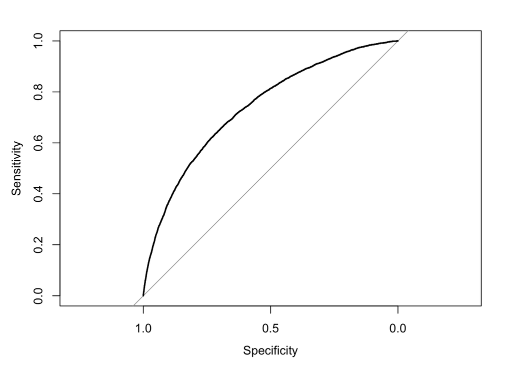

Since area under the curve is 0.74, which is smaller than 0.8. With the McFadden value, only 10.93% of target (will buy or not buy) is explained by the explanatory variables in the model. This model actually is not as good as we expected.

|  | x |
| --- | --- |
| Sensitivity | 0.9943561 |
| Specificity | 0.0436343 |
| Pos Pred Value | 0.8906396 |
| Neg Pred Value | 0.4967320 |
| Precision | 0.8906396 |
| Recall | 0.9943561 |
| F1 | 0.9396445 |
| Prevalence | 0.8867872 |
| Detection Rate | 0.8817823 |
| Detection Prevalence | 0.9900551 |
| Balanced Accuracy | 0.5189952 |

#### 5.2.2 PCA and PCR

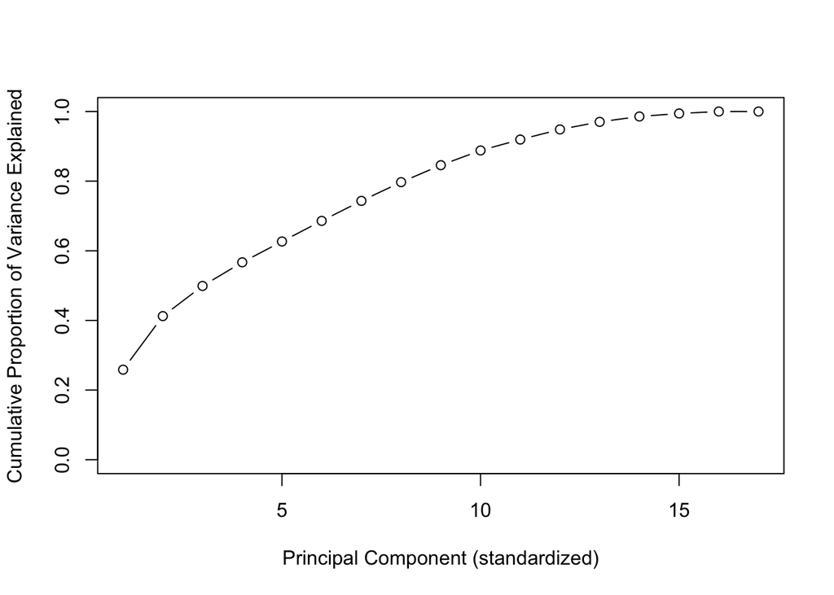

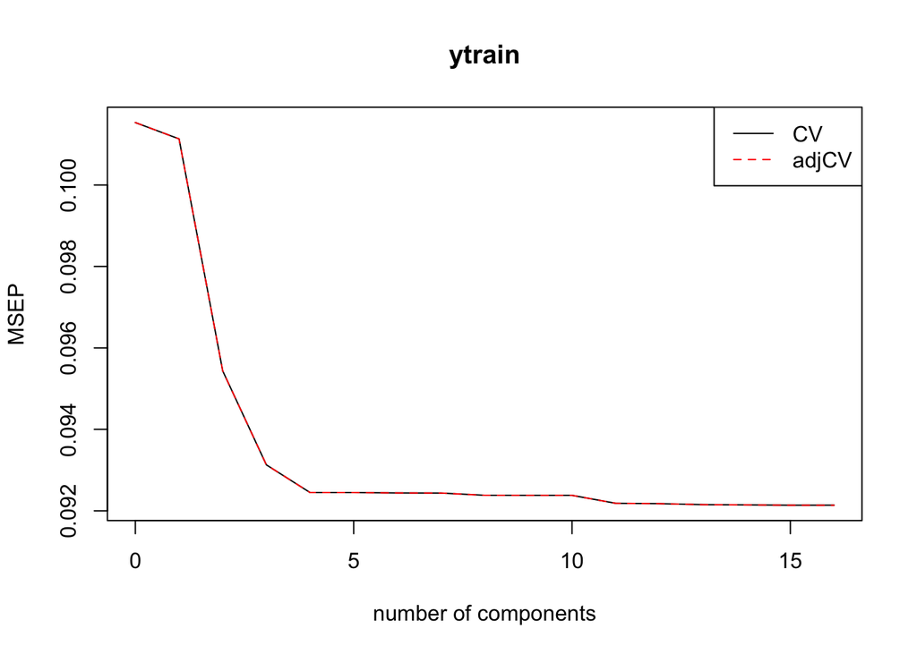

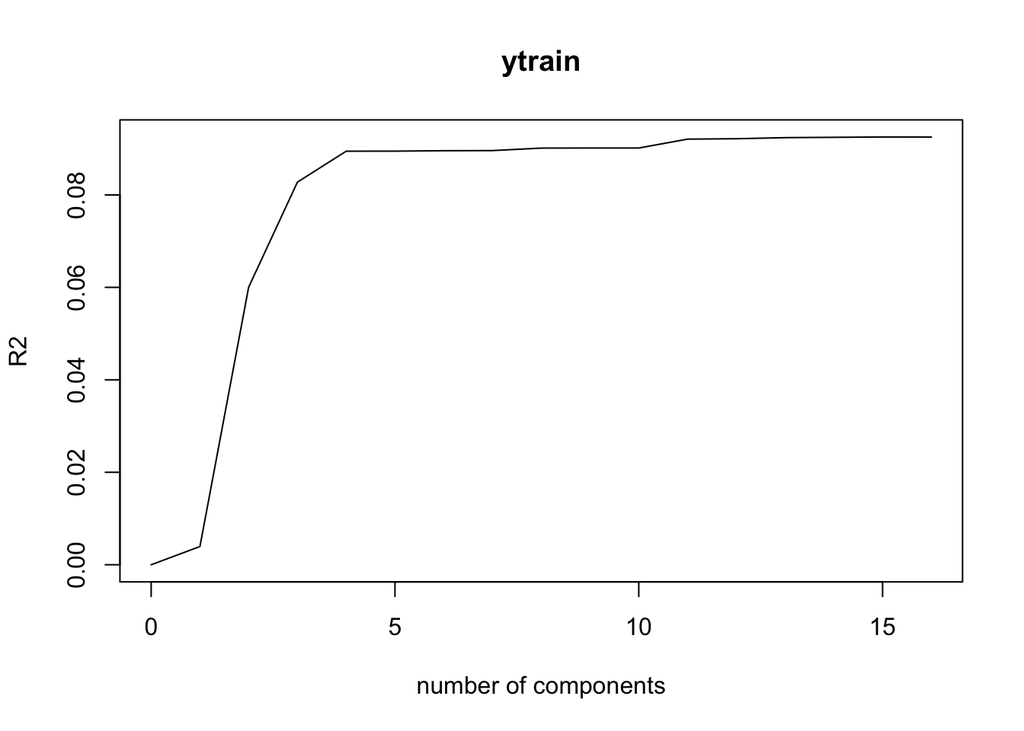

We choose Cross-validation (CV) method to evaluate our model. The first plot is mean square error prediction (MSE) and the second one is R squared (R2). Starting with the fourth component, the MSE value is becoming low，and at the same time that the R2 value gets bigger from the fourth one.

#### 5.2.3 KNN

We built model from 1NN to 21NN (k is odd number) to see what is the best k value and used confusion Matrix for evaluation. This part takes a long time so we post the result as “knn_accuracy_table.csv” which is saved in the ‘DataSet’ of our Github.

|  | k.1 | k.3 | k.5 | k.7 | k.9 | k.11 | k.13 | k.15 | k.17 | k.19 | k.21 |
| --- | --- | --- | --- | --- | --- | --- | --- | --- | --- | --- | --- |
| Sensitivity | 0.9075167 | 0.9607491 | 0.9813274 | 0.9902331 | 0.9943011 | 0.9963901 | 0.9978560 | 0.9984607 | 0.9984974 | 0.9986623 | 0.9991021 |
| Specificity | 0.2475958 | 0.1129611 | 0.0594230 | 0.0378929 | 0.0252619 | 0.0169370 | 0.0126310 | 0.0096168 | 0.0080379 | 0.0053108 | 0.0038754 |
| Pos Pred Value | 0.9042854 | 0.8945572 | 0.8909759 | 0.8896480 | 0.8887670 | 0.8881321 | 0.8878436 | 0.8876002 | 0.8874448 | 0.8871868 | 0.8870865 |
| Neg Pred Value | 0.2547253 | 0.2686924 | 0.2889044 | 0.3312422 | 0.3613963 | 0.3746032 | 0.4292683 | 0.4437086 | 0.4057971 | 0.3363636 | 0.3552632 |
| Precision | 0.9042854 | 0.8945572 | 0.8909759 | 0.8896480 | 0.8887670 | 0.8881321 | 0.8878436 | 0.8876002 | 0.8874448 | 0.8871868 | 0.8870865 |
| Recall | 0.9075167 | 0.9607491 | 0.9813274 | 0.9902331 | 0.9943011 | 0.9963901 | 0.9978560 | 0.9984607 | 0.9984974 | 0.9986623 | 0.9991021 |
| F1 | 0.9058982 | 0.9264724 | 0.9339716 | 0.9372496 | 0.9385768 | 0.9391516 | 0.9396407 | 0.9397723 | 0.9397015 | 0.9396298 | 0.9397682 |
| Prevalence | 0.8867872 | 0.8867872 | 0.8867872 | 0.8867872 | 0.8867872 | 0.8867872 | 0.8867872 | 0.8867872 | 0.8867872 | 0.8867872 | 0.8867872 |
| Detection Rate | 0.8047742 | 0.8519800 | 0.8702286 | 0.8781261 | 0.8817335 | 0.8835860 | 0.8848860 | 0.8854223 | 0.8854548 | 0.8856010 | 0.8859910 |
| Detection Prevalence | 0.8899560 | 0.9524042 | 0.9767140 | 0.9870489 | 0.9920863 | 0.9948813 | 0.9966688 | 0.9975463 | 0.9977575 | 0.9982125 | 0.9987650 |
| Balanced Accuracy | 0.5775562 | 0.5368551 | 0.5203752 | 0.5140630 | 0.5097815 | 0.5066635 | 0.5052435 | 0.5040388 | 0.5032676 | 0.5019865 | 0.5014888 |

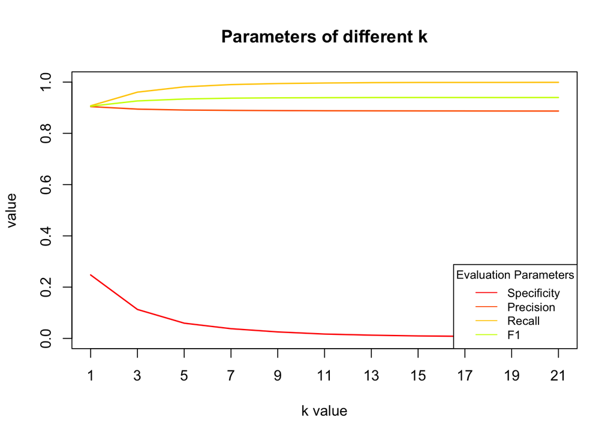

We tried k value as all odd numbers from 1 to 21, and found that when k value is 15, the F1 score is the highest, which is 0.9398. We chose a small k value to ensure the complexity of the model. It seems 15-nearest neighbors is a decent choice. In this case, the sensitivity is 0.9984, the specificity is 0.0096, the presision value is 0.8876.

#### 5.2.4 Decision Tree

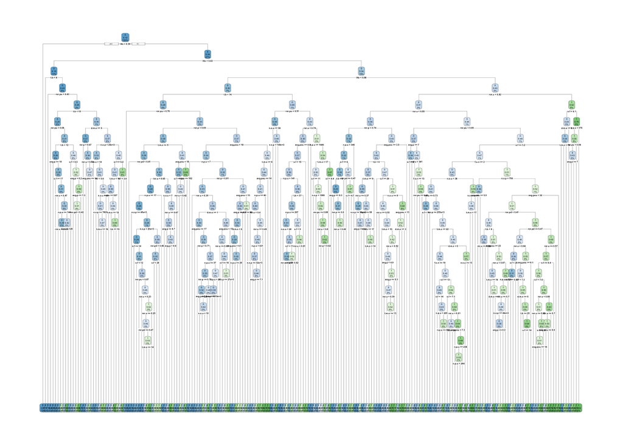

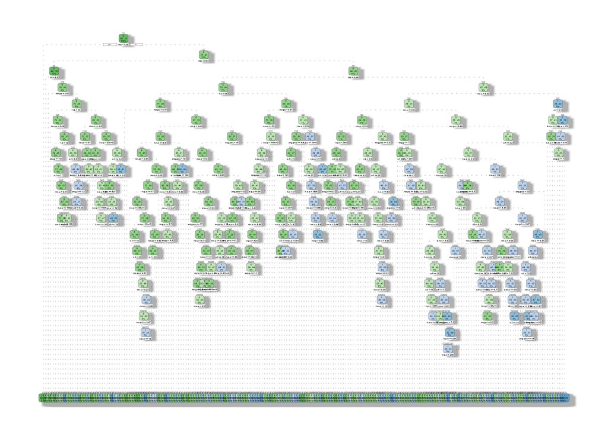

```
##  Accuracy
## 0.8871447
```

|  | x |
| --- | --- |
| Sensitivity | 0.9910027 |
| Specificity | 0.0736328 |
| Pos Pred Value | 0.8933840 |
| Neg Pred Value | 0.5109562 |
| Precision | 0.8933840 |
| Recall | 0.9910027 |
| F1 | 0.9396648 |
| Prevalence | 0.8867872 |
| Detection Rate | 0.8788086 |
| Detection Prevalence | 0.9836851 |
| Balanced Accuracy | 0.5323178 |

The result of decision tree model shows that the F1 score is 0.9397. We can also notice that sensitivity is (recall rate) is 0.9910, specificity is 0.0736, overall accuracy is 0.8871 and precision is 0.8933.

## Chapter 6 - Summary

Third, due to the large amount of data, we only selected the first 10,000 users as our modeling sample. Even though this is the easiest way to achieve subset, it may not as propitiate as random sampling. However, users are independent with each other, so the way we select the data will not influece the modeling process.

## Chapter 7 - Reference

“The Instacart Online Grocery Shopping Dataset 2017”, Accessed from https://www.instacart.com/datasets/grocery-shopping-2017

## Appendix

### Data source

Link:https://www.kaggle.com/c/instacart-market-basket-analysis/data

### Task divisions

Ruth: EDA（code+analysis） + Slides

Zixuan: EDA（code+analysis）+ summary report

Qing: EDA（code+analysis）+ feature selection(idea+analysis)

Kaiqi: data preprocessing(code) + feature selection(code)

Zichu: model building and evaluation(code)

### Github

Githublink: https://github.com/Kelv1nYu/ItDsProj2